# MLearning_Assignment

## Task description

The goal of this machine learning task is to predict the way in which exercises were performed in the pml dataset that is provided. The data was obtained by letting 6 participants perform exercises while they wore accelerometers on the belt, forearm, arm, and dumbell. They were asked to perform barbell lifts correctly and incorrectly in 5 different ways. We will predict the way in which exercises were carried out, from the other variables that were provided.

## Data preparation

We first load the required packages and data, which consists of a test and training set.

```r
require("caret")
require("randomForest")
require("nnet")
require("rpart")
require("rattle")
require("e1071")
require("hydroGOF")

test.validation<-read.csv("pml-testing.csv",na.strings=c("", "NA"),header = TRUE,sep = ",")
train<-read.csv("pml-training.csv",na.strings=c("", "NA"),header = TRUE,sep=";")
names(test.validation)[160]="classe"
test.validation[,160]=as.factor(rep("A",20))
train=rbind(train,test.validation)
```

Note that the datasets have 160 variables, which means that there are 159 variables that we can use as a predictor, while the response variable is found in the last column. A lot of the predictor variables however contain (a lot of) missing values and we throw these variables out.

```r
nCol=ncol(train)
nRow=nrow(train)
naVector=rep(0,nCol)
for(i in 1:nCol){
  naVector[i]=sum(is.na(train[,i]))
  if(naVector[i]>0){
    naVector[i]<-0
  }
  else{
    naVector[i]<-1
  }
}

#Throw out columns that contain NA
selectionVector<-which(naVector==1)
trainNonNA<-train[,selectionVector]
trainNonNA<-trainNonNA[,-1]
```

Note that we remove the first column of the datasets, this is necessary as this column is increasing in value while the values in the last column, which we want to predict, are ordened. This means that including the first column in the prediction will give an almost perfect prediction by construction.

Then we split the trainNonNA dataset in a training and a testset. The model is trained on the training set and tested on the testset. The eventual performance is measured on a validation set, which is the test.validation set that we had constructed earlier.

```r
#Splitting data in training and testing set
set.seed(1001)

validation.NonNA<-tail(trainNonNA,20)
trainNonNA<-tail(trainNonNA,-20)

inTrain<-createDataPartition(y=trainNonNA[,1],p=0.7,list=FALSE)
training<-trainNonNA[inTrain,]
testing<-trainNonNA[-inTrain,]

tc <- trainControl(method="repeatedcv",number=5,repeats=3)
```

## Machine Learning approaches using cross validation

We train our classifiers on the training set and apply them on the testset in order to assess their performance. We use cross validation in order to make better use of the data.

### Multinomial regression

```r
mnom<-multinom(classe~.,training,trControl=tc)
t.mnom<-table(predict(mnom,testing),testing[,56])
sum(diag(t.mnom))/sum(t.mnom)
```

```
## [1] 0.6468389
```

We see from the last number that the performance of the multinomial classifer on the testset is almost 65%.

### Classification tree

The next approach that we use is the classification tree. The classification tree is discussed in the course, so I assume that no further background knowledge is necessary.

```r
rtree<-train(classe~.,method="rpart",training,trControl=tc)
t.rtree<-table(predict(rtree,testing),testing[,56])
sum(diag(t.rtree))/sum(t.rtree)
```

```
## [1] 0.4909925
```

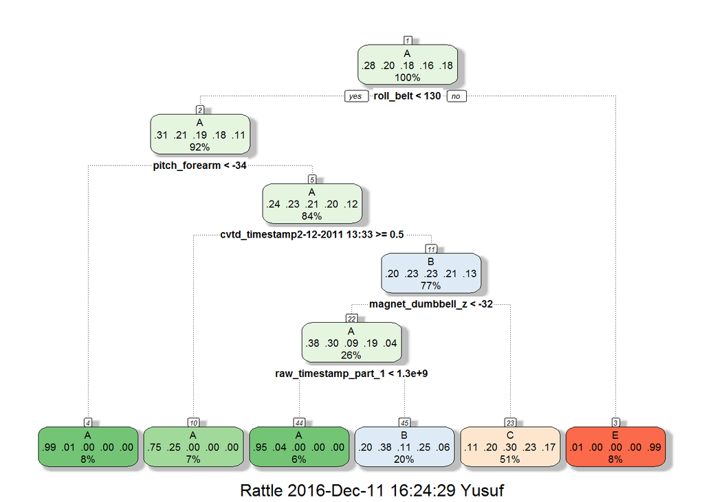

```r
fancyRpartPlot(rtree$finalModel)
```

### Random forest

We apply the random forest classifier.

```r
rforest<-randomForest(classe~.,training,trControl=tc)
t.rforest<-table(predict(rforest,testing),testing[,56])
sum(diag(t.rforest))/sum(t.rforest)
```

```
## [1] 0.9988103
```

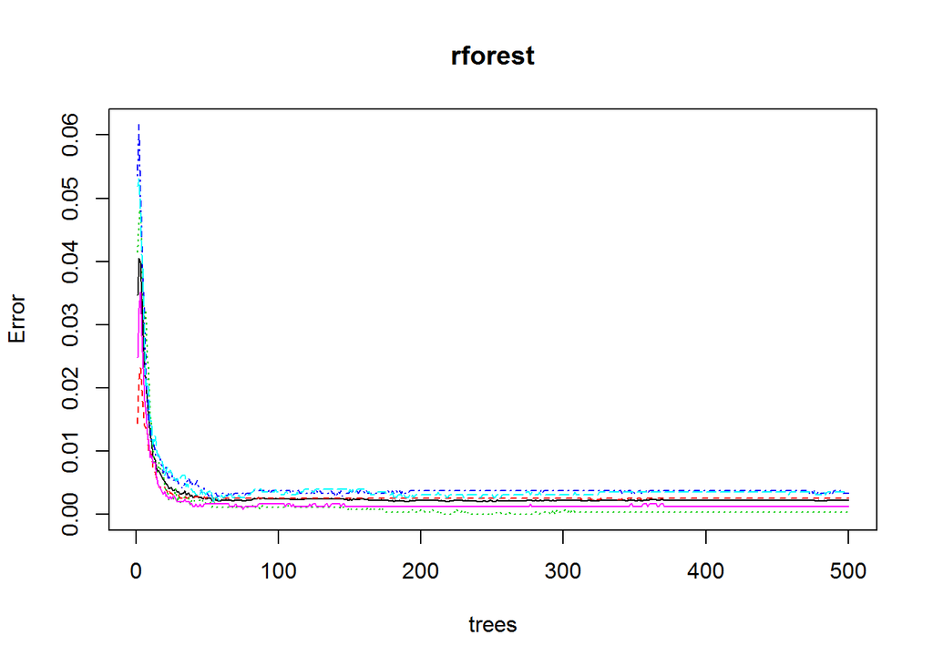

```r
plot(rforest)
```

### Support vector machines

The last method I want to apply is the support vector machines(svm) classifier, because I obtained good results while playing around with it. Two-value Svm chooses a hyperplane on the testset, that has the largest distance to the nearest training-data points of any class. The intuition behind this is that we can separate points using various hyperplanes, however the ‘best’ hyperplane should have a error margin (which is the distance until the nearest points) that is as large as possible. In R the support vector machine can understand that more than two categories exist and can also classify accordingly.See below for the results on the testset.

```r
rsvm<-svm(classe~.,training,trControl=tc)
t.svm<-table(predict(rsvm,testing),testing[,56])
sum(diag(t.svm))/sum(t.svm)
```

```
## [1] 0.9474847
```

See that we get an accuracy of almost 95%

## Classification on validation set

```r
predict(rsvm,validation.NonNA)
```

```
## 19623 19624 19625 19626 19627 19628 19629 19630 19631 19632 19633 19634
##     B     A     A     A     A     E     D     B     A     A     B     C
## 19635 19636 19637 19638 19639 19640 19641 19642
##     B     A     E     E     A     B     B     B
## Levels: A B C D E
```